# Introduction to MazamaSpatialPlots

Rachel Carroll, Mazama Science

2022-11-07

## Background

Maps colored by state and county (aka “chloropleth maps”) are among the most common data graphics and are used to convey everything from vote totals to economic and health statistics. Well designed maps involve a careful choice of map projections and colors for both the state/county fill and boundary lines. Unfortunately, creating beautiful maps in R is still somewhat involved.

## Installation

This package is designed to be used with [R](https://cran.r-project.org) (>= 3.5) and [RStudio](https://posit.co) so make sure you have those installed first.

Users will want to install the **devtools** package to have access to the latest development version of the package from GitHub.

The following packages should be installed by typing the following at the RStudio console:

```
# Note that vignettes require knitr and rmarkdown
install.packages('knitr')
install.packages('rmarkdown')
install.packages('MazamaSpatialUtils')
devtools::install_github('MazamaScience/MazamaSpatialPlots')
```

**MazamaSpatialPlots** requires spatial polygon data to plot the shapes of states and counties. These spatial datasets are provided by **MazamaSpatialUtils** and can be installed by running the following in the RStudio console:

```
library(MazamaSpatialUtils)
dir.create('~/Data/Spatial', recursive = TRUE)
setSpatialDataDir('~/Data/Spatial')
installSpatialData("USCensusStates_02")
installSpatialData("USCensusCounties_02")
```

## Features

Currently, **MazamaSpatialPlots** contains high level functions for creating choropleth maps for US counties and states:

- `countyMap()` - plot a choropleth map for county level data. Uses the `USCensusCounties_02` dataset for spatial polygons.
- `stateMap()` - plot a choropleth map for state level data. Uses the `USCensusStates_02` dataset for spatial polygons.

Additionally, **MazamaSpatialPlots** provides two example datasets formatted for use with the package’s functions:

- `example_US_stateObesity` - state level obesity rate
- `example_US_countyCovid` - county level COVID19 cases and deaths

## Input Data

The *SpatialPolygonsDataFrame* used to create a state or county map is provided by the **MazamaSpatialUtils** package once that is installed.

### State-level data

User provided data must be provided as simple dataframes. For the `stateMap()` function, the `data` input dataframe must have a `stateCode` column containing the 2-character US state code. Any other column of data can be used as the `parameter` by which states will be colored.

The following functions from **MazamaSpatialUtils** can help in creating the `stateCode` column if it does not already exist:

- `MazamaSpatialUtils::US_stateNameToCode()`
- `MazamaSpatialUtils::US_stateFIPSToCode()`

### County-level data

For county maps, the input `data` must contain a `countyFIPS` column uniquely identifying each county. The `MazamaSpatialUtils::US_countyCodes` dataset can be used to determine the `countyFIPS` codes.

## Example Maps

### Example state map

Here we create a state map using the package `example_US_stateObesity` dataset showing the obesity rate for each state in the United States. A single call to the `stateMap()` function is all that is required. Customization is performed entirely through function arguments.

```r
library(MazamaSpatialPlots)

# Look at input data
head(example_US_stateObesity)
```

```
#>   stateCode  stateName obesityRate
#> 1        TX      Texas        32.4
#> 2        CA California        24.2
#> 3        KY   Kentucky        34.6
#> 4        GA    Georgia        30.7
#> 5        WI  Wisconsin        30.7
#> 6        OR     Oregon        30.1
```

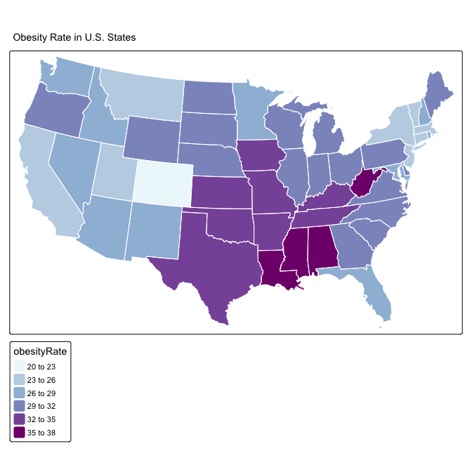

```r
# Create the map
stateMap(
  data = example_US_stateObesity,
  parameter = 'obesityRate',
  breaks = seq(20, 38, 3),
  palette = 'brewer.bu_pu',
  stateBorderColor = 'white',
  title = "Obesity Rate in U.S. States"
)
```

MazamaSpatialPlots.R

### Example county map

For the `countyMap()` example, we use COVID19 case data from June 01, 2020.

```r
# Look at the input data
head(example_US_countyCovid)
```

```
#> # A tibble: 6 × 6
#>   stateCode stateName countyFIPS countyName cases deaths
#>   <chr>     <chr>     <chr>      <chr>      <int>  <int>
#> 1 AL        Alabama   01001      Autauga      234      5
#> 2 AL        Alabama   01003      Baldwin      306      9
#> 3 AL        Alabama   01005      Barbour      173      1
#> 4 AL        Alabama   01007      Bibb          79      1
#> 5 AL        Alabama   01009      Blount        65      1
#> 6 AL        Alabama   01011      Bullock      210      6
```

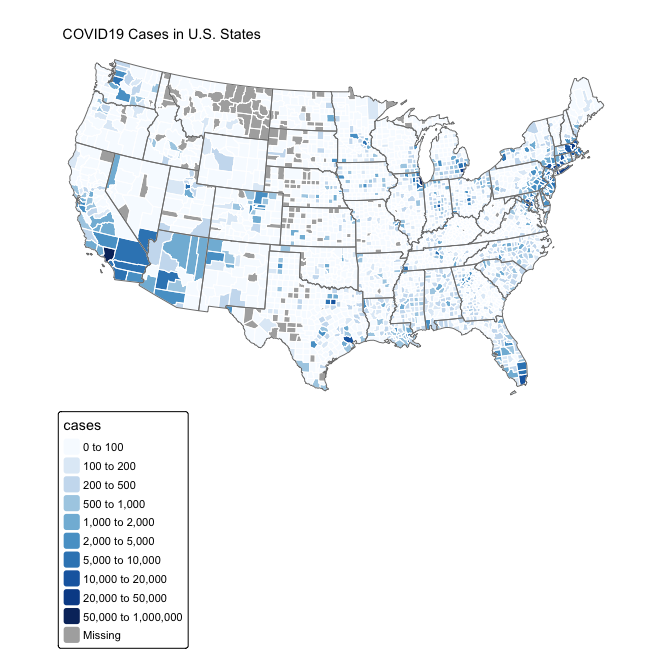

```r
# Create the map
countyMap(
  data = example_US_countyCovid,
  parameter = "cases",
  breaks = c(0,100,200,500,1000,2000,5000,10000,20000,50000,1e6),
  countyBorderColor = "white",
  title = "COVID19 Cases in U.S. States"
)
```

MazamaSpatialPlots.R